# Análise de Regressão

Jair Guedes, Lucas Aurelio, Rafaelle Amorim

13 de outubro de 2016

Nesse trabalho, iremos realizar uma **análise sobre um Modelo de Regressão Linear Múltipla(MRLM)**.  
Os dados utilizados na construção do modelo possuem 3 variáveis:

- Dependente/resposta: y.salario
- Independente/fator: x1.educação
- Independente/fator: x2.experiencia

Primeiro, vamos observar a distribuição dos dados para *x1.educacao* e *y.salario*:

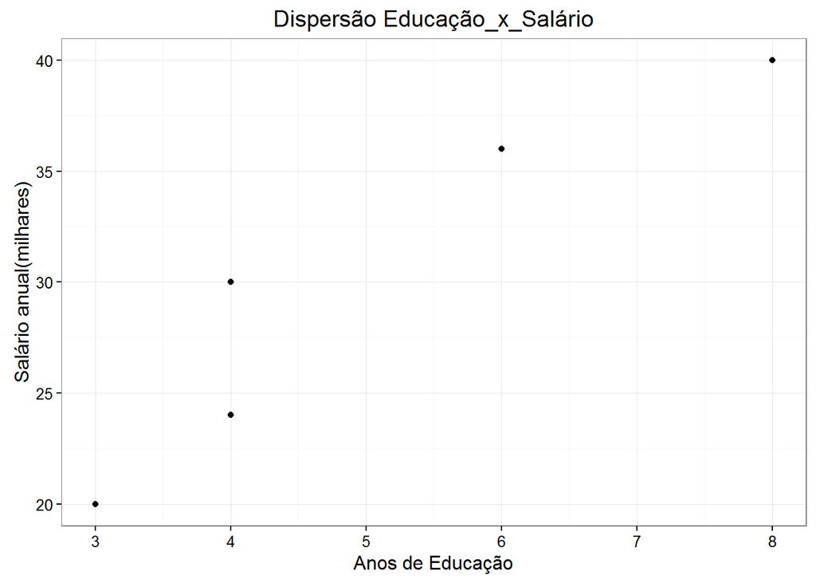

Podemos observar que há um certo comportamento crescente para a distribuição entre as variáveis educação e salário. O que pode ser um indício da uma relação linear positiva.  
Já para *x2.experiencia* e *y.salario*, temos:

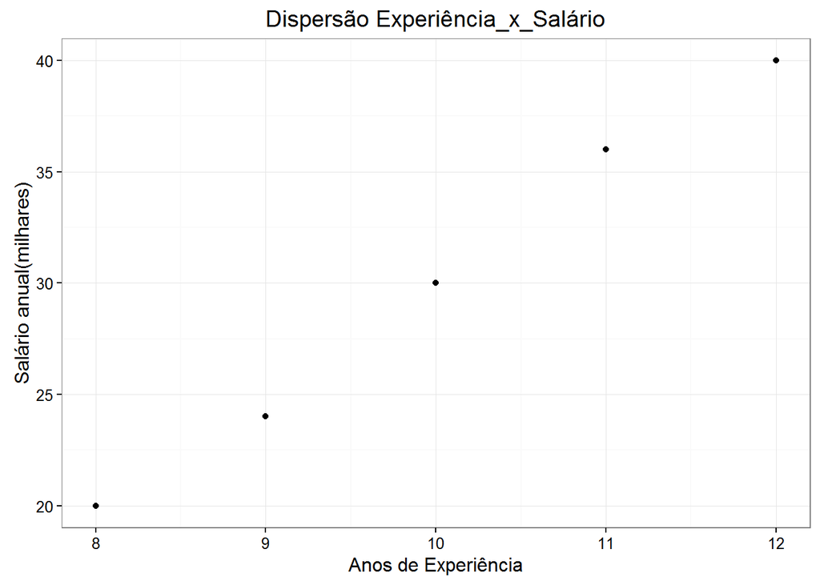

Imediatamente percebemos que a relação entre essas duas variáveis é maior que a relação entre *x1.educacao* e *y.salario*, uma vez que se passada uma linha reta o mais próximo possível dos pontos (ideia de um modelo linear) as diferenças serão menores. Logo, há uma boa probabilidade de existir uma relação linear entre essas duas variáveis.

Agora, vamos analisar a correlação das variáveis.  
Primeiro, temos que transformar o dados do dataframe em matrizes:

```r
#matriz com os valores de sálarios anuais
salario <- as.matrix(dados.sal.edu.exp$y.salario)
#matriz com os valores de anos de educação
educacao <- as.matrix(dados.sal.edu.exp$x1.educacao)
#matriz com os calores de anos de experiência
experiencia <- as.matrix(dados.sal.edu.exp$x2.experiencia)
```

Agora, com essas matrizes, podemos estimar os coeficientes de correlação entre as variáveis. Assim, para a correlação entre *x1.educacao* e *y.salario*, temos:

```r
p.educacao.salario <- cor(salario,educacao)
p.educacao.salario
```

```
##           [,1]
## [1,] 0.9398255
```

E para a correlação entre *x2.experiencia* e *y.salario*, temos:

```r
p.experiencia.salario <- cor(salario,experiencia)
p.experiencia.salario
```

```
##           [,1]
## [1,] 0.9970545
```

Ambos os coeficientes de correlação são maiores que 0.9, o que indica uma correlação muito forte.  
Assim, considerando como hipótese nula:

- Ho: ρ = 0

para cada uma das correlações entre as variáveis, podemos realizar o teste de significância. Primeiro para a correlação entre *x1.educacao* e *y.salario*:

```r
cor.test(dados.sal.edu.exp$y.salario,dados.sal.edu.exp$x1.educacao)
```

```
##
##  Pearson's product-moment correlation
##
## data:  dados.sal.edu.exp$y.salario and dados.sal.edu.exp$x1.educacao
## t = 4.7645, df = 3, p-value = 0.01756
## alternative hypothesis: true correlation is not equal to 0
## 95 percent confidence interval:
##  0.3369509 0.9961269
## sample estimates:
##       cor
## 0.9398255
```

Agora para *x2.experiencia* e *y.salario*:

```r
cor.test(dados.sal.edu.exp$y.salario,dados.sal.edu.exp$x2.experiencia)
```

```
##
##  Pearson's product-moment correlation
##
## data:  dados.sal.edu.exp$y.salario and dados.sal.edu.exp$x2.experiencia
## t = 22.517, df = 3, p-value = 0.0001918
## alternative hypothesis: true correlation is not equal to 0
## 95 percent confidence interval:
##  0.9539256 0.9998155
## sample estimates:
##       cor
## 0.9970545
```

Assim, como os ‘p-valor’ dos testes são muito próximos de zero, rejeitamos Ho.

Nessa etapa do trabalho vamos estimar os valores de βi. Para isso, temos as matrizes:

```r
#matriz com os valores de salario
matrizY <- salario
matrizY
```

```
##      [,1]
## [1,]   30
## [2,]   20
## [3,]   36
## [4,]   24
## [5,]   40
```

```r
#matriz com os valores de anos de educação e anos de experiência
matrizX <- cbind(c(1,1,1,1,1),educacao,experiencia)
matrizX
```

```
##      [,1] [,2] [,3]
## [1,]    1    4   10
## [2,]    1    3    8
## [3,]    1    6   11
## [4,]    1    4    9
## [5,]    1    8   12
```

Agora, estimamos os coeficientes.

```r
transX <- t(matrizX)
transXX <- transX%*%matrizX
invTransXX <- solve(transXX)
transXY <- transX%*%matrizY

matrizCoeficientes <- invTransXX%*%transXY
matrizCoeficientes
```

```
##        [,1]
## [1,] -23.75
## [2,]  -0.25
## [3,]   5.50
```

Logo, temos:

- β0 = -23.75
- β1 = -0.25
- β2 = 5.5

Agora, a partir da matriz dos coeficientes que estimamos, e da matriz dos valores de Xi(*matrizX*), podemos obter a matriz de estimativas dos valores previstos:

```r
matrizYi <- matrizX%*%matrizCoeficientes
matrizYi
```

```
##       [,1]
## [1,] 30.25
## [2,] 19.50
## [3,] 35.25
## [4,] 24.75
## [5,] 40.25
```

Assim, temos os valores acima como o vetor dos valores previstos.

Para calcular a Soma de Quadrados Total (SQtotal) temos que: SQtotal = somatorio (Yi - media(Y))²

```r
Ysalario = mean(unlist(dados.sal.edu.exp["y.salario"]))
SQtotal = sum((unlist(dados.sal.edu.exp["y.salario"]) - Ysalario)**2)
SQtotal
```

```
## [1] 272
```

Para calcular a Soma de Quadrados de Regressão (SQReg) temos que: SQReg = somatorio(ˆYi - media(Y))²

```r
SQReg = sum((unlist(matrizYi) - Ysalario)**2)
SQReg
```

```
## [1] 270.5
```

Para calcular o coeficiente de determinação R² = SQReg/SQtotal, temos que:

```r
RQuad = SQReg/SQtotal
RQuad
```

```
## [1] 0.9944853
```

o R² de um modelo é 0.9944853, isto significa que 99.45% da variável dependente consegue ser explicada pelos regressores presentes no modelo.

(f)Realize uma ANOVA (Analise de Variancia) ao ńıvel de 5% de significancia e diga s estatisticamente significativo dizer que pelo menos uma das variaveis independentes exerce influencia sobre a variavel dependente/resposta y Consideramos:

- Ho:β0=β1=β2=0
- H1: pelo menos um coeficiente é diferente de zero

Como primeiro passo da ANOVA, vamos encontrar o valor da distribuição F para *k*(grau de liberdade do numerador) e *n-k-1*(grau de liberdade do denominador):

```r
k <- 2
n <- 5
valueFtab <- qf(.95,k,n-k-1)
valueFtab
```

```
## [1] 19
```

Agora, vamos calcular o F a partir das matrizes em questão. Temos que:

- F = QMReg/QMRes

Como já temos o valor de SQReg (visto mais acima), só precisamos dividir pelo grau de liberdade para obtermos QMReg. Então, temos:

```r
QMReg <- SQReg/k
QMReg
```

```
## [1] 135.25
```

E agora calculamos o valor de QMRes:

```r
SQRes <- t(matrizY)%*%matrizY - (t(matrizCoeficientes)%*%t(matrizX)%*%matrizY)
QMRes <- SQRes/(n-k-1)
QMRes
```

```
##      [,1]
## [1,] 0.75
```

A partir desses dois valores, podemos calcular F:

```r
valorF <- QMReg/QMRes
valorF
```

```
##          [,1]
## [1,] 180.3333
```

Como o valor de F(=QMReg/QMRes) é bem maior que o valor da distribuição F para os graus de liberdade *k* e *n-k-1*, rejeitamos Ho. Ou seja, é estatisticamente significativo dizer que pelo menos uma das variaveis independentes exerce influencia sobre a variavel resposta y.

(g)Realize testes marginais (t de Student) para testar individualmente se cada variável independente exerce influência sobre a variável dependente y.

Utilizando a função t.test() do R, vamos verificar se a educação exerce influência sobre o salário e se a variável experiência exerce influência sobre o salário.

```r
t.test(salario,educacao, var.equal=FALSE, paired=FALSE)
```

```
##
##  Welch Two Sample t-test
##
## data:  salario and educacao
## t = 6.5881, df = 4.469, p-value = 0.001845
## alternative hypothesis: true difference in means is not equal to 0
## 95 percent confidence interval:
##  14.88616 35.11384
## sample estimates:
## mean of x mean of y
##        30         5
```

```r
t.test(salario, experiencia, var.equal=FALSE, paired=FALSE)
```

```
##
##  Welch Two Sample t-test
##
## data:  salario and experiencia
## t = 5.3262, df = 4.2937, p-value = 0.004889
## alternative hypothesis: true difference in means is not equal to 0
## 95 percent confidence interval:
##   9.849788 30.150212
## sample estimates:
## mean of x mean of y
##        30        10
```

Como podemos ver o valor p para a relação entre salário e educação é igual a 0.001845 e para a relação salario e experiência é igual a 0.004889.O que indica uma influência das variáveis dependentes sobre a independente, pois os dois valores p encontrados são menores que 0.05.

8. Diga qual é o salário anual estimado se um funcionário escolhido ao acaso tem 5 anos de educação após o ensino médio e 10 anos de experiência na empresa. . Temos que o salário previsto será igual a B0 + B1 * X1 + B2 * X2, realizando os cálculos temos que o salário previsto será igual a 30.

```r
salario.previsto <- -23.75 + 5*-0.25 + 10*5.50
salario.previsto
```

```
## [1] 30
```